# AUTO$^2$ and AUTO-Demos : *lrz* - The Lorenz equation.

**This is an example on how to use AUTO$^2$ to explore the AUTO Demos *lrz* bifurcations and solutions.**

This example is concerned with the famous [Lorenz 63](https://en.wikipedia.org/wiki/Lorenz_system) model for [atmospheric convection](https://en.wikipedia.org/wiki/Lorenz_system#Model_for_atmospheric_convection), depicting the famous "butterfly wings".

[figure not shown]

Source: Wikipedia Commons

Here, one can see a sample solution on the attractor when $\rho = 28$, $\sigma = 10$, and $\beta = 8/3$ (see model equations below).

The equations of the model are given by:

$$ \dot x = \sigma (y-x) $$ $$ \dot y = x \rho - y - x z $$ $$ \dot z = x y - \beta z $$

The free parameter in the current example notebook is $\rho$ . Other parameters are fixed.

We are thus going to find the fixed points and periodic orbits of this system and continue them by varying $\rho$.

#### References

- Lorenz, Edward Norton (1963). "Deterministic nonperiodic flow". *Journal of the Atmospheric Sciences*. **20** (2): 130–141. [doi:10.1175/1520-0469(1963)020<0130:DNF>2.0.CO;2](https://doi.org/10.1175%2F1520-0469%281963%29020%3C0130%3ADNF%3E2.0.CO%3B2).
- Barrio, R., Shilnikov, A., & Shilnikov, L. (2012). Kneadings, symbolic dynamics and painting Lorenz chaos. *International Journal of Bifurcation and Chaos*, **22**(04), 1230016. [doi:10.1142/S0218127412300169](https://doi.org/10.1142/S0218127412300169)

## Code

First we set the Python path if needed:

```python
import sys, os
```

```python
sys.path.extend([os.path.abspath('../../../')])
```

And load the needed libraries, including AUTO$^2$:

```python
import numpy as np
from numba import njit
from scipy.optimize import root
from scipy.integrate import solve_ivp
```

```python
from auto2.diagrams.bifurcations import BifurcationDiagram
```

```
2025-11-03 17:11:12,517 INFO: Module config.py -- Using auto-AUTO (AUTO² or auto2) -- An AUTO-07p automatic search algorithm codebase
2025-11-03 17:11:12,517 INFO: Module config.py -- Read AUTO-07p manual first before using it. Wishing you a happy continuation, have fun !
2025-11-03 17:11:12,518 INFO: Module config.py -- General logging messages related can be found in the file "auto2.log"
```

Creating the model equations

```python
@njit
def lrz(X, rho, beta, sigma):
    x = X[0]
    y = X[1]
    z = X[2]
    F = np.zeros(3)
    F[0] = sigma * (y - x)
    F[1] = rho * x - y - x * z
    F[2] = x * y - beta * z
    return F

@njit
def lrzt(t, X, rho, beta, sigma):
    return lrz(X, rho, beta, sigma)
```

and define a set of standard parameters:

```python
params = {
    'rho': 24.5,
    'beta': 8./3,
    'sigma': 10.,
}
```

For reference later, we can compute a long trajectory on the attractor of this model:

```python
#first a transient
ic = np.zeros(3) + 0.01
transient = solve_ivp(lrzt, (0., 1000.), ic, args=tuple(params.values()))
```

```python
# then the trajectory itself
ic = transient['y'][:, -1]
trajectory = solve_ivp(lrzt, (0., 1000.), ic, args=tuple(params.values()))
```

Finding all the fixed points of the Lorenz 63 system for $\beta = 8/3$, $\sigma = 10$ and $\rho = 0$ :

```python
params['rho'] = 0.
nsearch = 1000

# Start on random initial conditions
ic = 2 * (np.random.rand(nsearch, 3) - 0.5) * 10.

eps = 1.e-6
fixed_points = dict()

sol_idx = 1
for i in range(nsearch):
    sol = root(lrz, ic[i, :], args=tuple(params.values()))
    if sol.success:
        for idx in fixed_points:
            if np.linalg.norm(fixed_points[idx] - sol.x) < eps:
                break
        else:
            fixed_points[sol_idx] = sol.x
            sol_idx+=1
```

We have now the list of fixed points `fixed_points` and parameters dictionnary `params` that AUTO$^2$ will have to continue

```python
initial_points = list()

for p in fixed_points:
    initial_points.append({'parameters': params, 'initial_data': fixed_points[p]})
```

and thus we are now ready to compute the diagram of fixed points as a function of $\rho$. Note that we specify that the bifurcation diagram object must load the ̀`lrz.f90` and `c.lrz` files where the Lorenz 63 model equations and continuation parameters have been written:

```python
b = BifurcationDiagram('lrz')

b.compute_fixed_points_diagram(initial_points,extra_comparison_parameters=['x', 'y'], comparison_tol=[1.e-1] * 3,
                               ICP=['rho'], NMX=300, UZSTOP={'rho':[-10.,40.]}, UZR={'rho': list(np.arange(2, 30, 2.5))}, NPR=0)
```

```
2025-11-03 17:11:35,712 INFO: Model lrz -- Cont. Param. rho -- Module bifurcations.py -- Starting a new bifurcation diagram along parameter rho.
2025-11-03 17:11:35,714 INFO: Model lrz -- Cont. Param. rho -- Module bifurcations.py -- Files will be loaded from and saved in the folder /home/mcrucifix/Git/auto/auto-AUTO/notebooks/auto-demos/lrz.
2025-11-03 17:11:35,715 INFO: Model lrz -- Cont. Param. rho -- Module bifurcations.py -- Logs related to this diagram can be found in the /home/mcrucifix/Git/auto/auto-AUTO/notebooks/auto-demos/lrz/auto2_lrz_rho.log file.
2025-11-03 17:11:35,716 INFO: Model lrz -- Cont. Param. rho -- Module bifurcations.py -- Starting the computation of the fixed points bifurcation diagram with model lrz.
2025-11-03 17:11:35,717 INFO: Model lrz -- Cont. Param. rho -- Module bifurcations.py -- Continuing provided fixed points.
```

```
Runner configured
gfortran -g -fopenmp -O -c lrz.f90 -o lrz.o
gfortran -g -fopenmp -O lrz.o -o lrz.exe /home/mcrucifix/Git/auto/auto-07p/lib/*.o
Starting lrz ...

  BR    PT  TY  LAB      rho         L2-NORM          x             y             z
   1     1  EP    1   0.00000E+00   0.00000E+00   0.00000E+00   0.00000E+00   0.00000E+00
   1     5  BP    2   1.00000E+00   0.00000E+00   0.00000E+00   0.00000E+00   0.00000E+00
   1     7  UZ    3   2.00000E+00   0.00000E+00   0.00000E+00   0.00000E+00   0.00000E+00
   1    12  UZ    4   4.50000E+00   0.00000E+00   0.00000E+00   0.00000E+00   0.00000E+00
   1    17  UZ    5   7.00000E+00   0.00000E+00   0.00000E+00   0.00000E+00   0.00000E+00
   1    22  UZ    6   9.50000E+00   0.00000E+00   0.00000E+00   0.00000E+00   0.00000E+00
   1    27  UZ    7   1.20000E+01   0.00000E+00   0.00000E+00   0.00000E+00   0.00000E+00
   1    32  UZ    8   1.45000E+01   0.00000E+00   0.00000E+00   0.00000E+00   0.00000E+00
   1    37  UZ    9   1.70000E+01   0.00000E+00   0.00000E+00   0.00000E+00   0.00000E+00
   1    42  UZ   10   1.95000E+01   0.00000E+00   0.00000E+00   0.00000E+00   0.00000E+00
   1    47  UZ   11   2.20000E+01   0.00000E+00   0.00000E+00   0.00000E+00   0.00000E+00
   1    52  UZ   12   2.45000E+01   0.00000E+00   0.00000E+00   0.00000E+00   0.00000E+00
   1    57  UZ   13   2.70000E+01   0.00000E+00   0.00000E+00   0.00000E+00   0.00000E+00
   1    62  UZ   14   2.95000E+01   0.00000E+00   0.00000E+00   0.00000E+00   0.00000E+00
   1    83  UZ   15   4.00000E+01   0.00000E+00   0.00000E+00   0.00000E+00   0.00000E+00

 Total Time    0.648E-02
lrz ... done
Runner configured
Starting lrz ...

  BR    PT  TY  LAB      rho         L2-NORM          x             y             z
   1     1  EP    1   0.00000E+00   0.00000E+00   0.00000E+00   0.00000E+00   0.00000E+00
   1    23  UZ    2  -1.00000E+01   0.00000E+00   0.00000E+00   0.00000E+00   0.00000E+00

 Total Time    0.148E-02
```

```
2025-11-03 17:11:36,319 INFO: Model lrz -- Cont. Param. rho -- Module bifurcations.py -- Saving valid branch 1 emanating from detected fixed point 1.
2025-11-03 17:11:36,320 INFO: Model lrz -- Cont. Param. rho -- Module bifurcations.py -- Provided fixed points continuation has ended.
2025-11-03 17:11:36,321 INFO: Model lrz -- Cont. Param. rho -- Module bifurcations.py -- Eventually continuing detected branching points.
2025-11-03 17:11:36,322 INFO: Model lrz -- Cont. Param. rho -- Module bifurcations.py -- Continuing branching points of branch: 1
2025-11-03 17:11:36,323 INFO: Model lrz -- Cont. Param. rho -- Module bifurcations.py -- Treating forward direction.
2025-11-03 17:11:36,324 INFO: Model lrz -- Cont. Param. rho -- Module bifurcations.py -- Continuing fixed point out of branching point 1
```

```
lrz ... done
Runner configured
Starting lrz ...

  BR    PT  TY  LAB      rho         L2-NORM          x             y             z
   2    17  UZ   16   2.00000E+00   2.51661E+00   1.63299E+00   1.63299E+00   1.00000E+00
   2    27  UZ   17   4.50000E+00   5.56028E+00   3.05505E+00   3.05505E+00   3.50000E+00
   2    35  UZ   18   7.00000E+00   8.24621E+00   4.00000E+00   4.00000E+00   6.00000E+00
   2    43  UZ   19   9.49994E+00   1.08435E+01   4.76094E+00   4.76094E+00   8.49994E+00
   2    51  UZ   20   1.20000E+01   1.34039E+01   5.41602E+00   5.41602E+00   1.10000E+01
   2    59  UZ   21   1.45000E+01   1.59452E+01   6.00000E+00   6.00000E+00   1.35000E+01
   2    67  UZ   22   1.70000E+01   1.84752E+01   6.53197E+00   6.53197E+00   1.60000E+01
   2    75  UZ   23   1.95000E+01   2.09980E+01   7.02377E+00   7.02377E+00   1.85000E+01
   2    83  UZ   24   2.20000E+01   2.35159E+01   7.48331E+00   7.48331E+00   2.10000E+01
   2    91  UZ   25   2.45000E+01   2.60304E+01   7.91623E+00   7.91623E+00   2.35000E+01
   2    92  HB   26   2.47368E+01   2.62685E+01   7.95602E+00   7.95602E+00   2.37368E+01
   2    99  UZ   27   2.70000E+01   2.85424E+01   8.32666E+00   8.32666E+00   2.60000E+01
   2   107  UZ   28   2.95000E+01   3.10524E+01   8.71780E+00   8.71780E+00   2.85000E+01
   2   137  UZ   29   4.00000E+01   4.15812E+01   1.01980E+01   1.01980E+01   3.90000E+01

 Total Time    0.878E-02
lrz ... done
Runner configured
Starting lrz ...

  BR    PT  TY  LAB      rho         L2-NORM          x             y             z
   2    17  UZ   16   2.00000E+00   2.51661E+00  -1.63299E+00  -1.63299E+00   1.00000E+00
   2    27  UZ   17   4.50000E+00   5.56028E+00  -3.05505E+00  -3.05505E+00   3.50000E+00
   2    35  UZ   18   7.00000E+00   8.24621E+00  -4.00000E+00  -4.00000E+00   6.00000E+00
   2    43  UZ   19   9.49994E+00   1.08435E+01  -4.76094E+00  -4.76094E+00   8.49994E+00
   2    51  UZ   20   1.20000E+01   1.34039E+01  -5.41602E+00  -5.41602E+00   1.10000E+01
   2    59  UZ   21   1.45000E+01   1.59452E+01  -6.00000E+00  -6.00000E+00   1.35000E+01
   2    67  UZ   22   1.70000E+01   1.84752E+01  -6.53197E+00  -6.53197E+00   1.60000E+01
   2    75  UZ   23   1.95000E+01   2.09980E+01  -7.02377E+00  -7.02377E+00   1.85000E+01
   2    83  UZ   24   2.20000E+01   2.35159E+01  -7.48331E+00  -7.48331E+00   2.10000E+01
   2    91  UZ   25   2.45000E+01   2.60304E+01  -7.91623E+00  -7.91623E+00   2.35000E+01
   2    92  HB   26   2.47368E+01   2.62685E+01  -7.95602E+00  -7.95602E+00   2.37368E+01
   2    99  UZ   27   2.70000E+01   2.85424E+01  -8.32666E+00  -8.32666E+00   2.60000E+01
   2   107  UZ   28   2.95000E+01   3.10524E+01  -8.71780E+00  -8.71780E+00   2.85000E+01
   2   137  UZ   29   4.00000E+01   4.15812E+01  -1.01980E+01  -1.01980E+01   3.90000E+01

 Total Time    0.821E-02
lrz ... done
```

```
2025-11-03 17:11:36,538 INFO: Model lrz -- Cont. Param. rho -- Module bifurcations.py -- Saving valid branch 2 emanating from branch 1.
2025-11-03 17:11:36,539 INFO: Model lrz -- Cont. Param. rho -- Module bifurcations.py -- Treating backward direction.
2025-11-03 17:11:36,539 INFO: Model lrz -- Cont. Param. rho -- Module bifurcations.py -- Continuing branching points of branch: 2
2025-11-03 17:11:36,540 INFO: Model lrz -- Cont. Param. rho -- Module bifurcations.py -- Treating forward direction.
2025-11-03 17:11:36,541 INFO: Model lrz -- Cont. Param. rho -- Module bifurcations.py -- Treating backward direction.
2025-11-03 17:11:36,542 INFO: Model lrz -- Cont. Param. rho -- Module bifurcations.py -- Fixed points bifurcation diagram computation is over.
2025-11-03 17:11:36,543 INFO: Model lrz -- Cont. Param. rho -- Module bifurcations.py -- All possible fixed point branches have been computed.
```

We can now plot the result as functions of $\rho$ and $L^2$ norm :

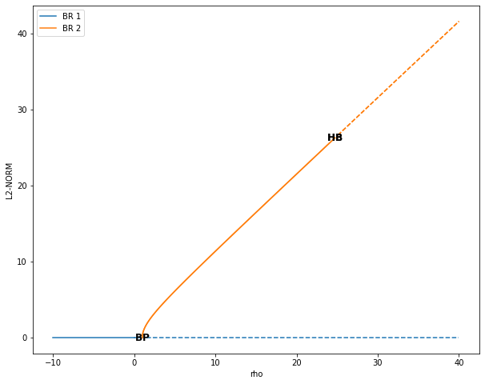

```python
b.plot_fixed_points_diagram();
```

and also as functions of $x$ and $y$ :

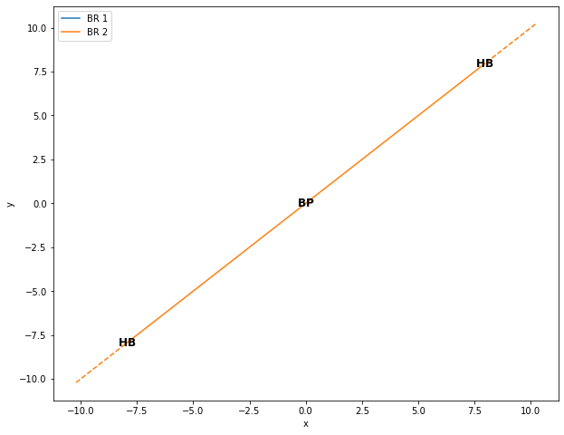

```python
b.plot_fixed_points_diagram((2,3));
```

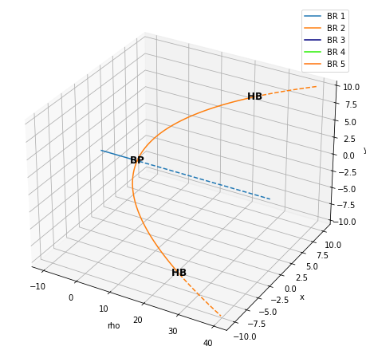

```python
b.plot_fixed_points_diagram_3D(('rho','x','y'));
```

We see that at 2 branches were found. The last one is symmetric and present distinct Hopf bifurcations.

We can continue periodic orbits out of these Hopf bifurcations :

```python
b.compute_periodic_orbits_diagram(
    3,
    extra_comparison_parameters=['x', 'y'],
    max_number_bp=None,
    comparison_tol=[1.e-3, 1.e-3, 1.e-3],
    ICP=['rho']
)
```

```
2025-11-03 17:12:05,608 INFO: Model lrz -- Cont. Param. rho -- Module bifurcations.py -- Starting the computation of the periodic orbits bifurcation diagram with model lrz.
2025-11-03 17:12:05,610 INFO: Model lrz -- Cont. Param. rho -- Module bifurcations.py -- Computing periodic orbits up to level 3
2025-11-03 17:12:05,612 INFO: Model lrz -- Cont. Param. rho -- Module bifurcations.py -- NMX parameters was not set, so setting it to 9000 points.
2025-11-03 17:12:05,613 INFO: Model lrz -- Cont. Param. rho -- Module bifurcations.py -- First, beginning computation of the periodic orbits from Hopf bifurcations.
2025-11-03 17:12:05,614 INFO: Model lrz -- Cont. Param. rho -- Module bifurcations.py -- Computing Hopf bifurcations of branch 1
2025-11-03 17:12:05,616 INFO: Model lrz -- Cont. Param. rho -- Module bifurcations.py -- Treating forward direction.
2025-11-03 17:12:05,617 INFO: Model lrz -- Cont. Param. rho -- Module bifurcations.py -- Treating backward direction.
2025-11-03 17:12:05,618 INFO: Model lrz -- Cont. Param. rho -- Module bifurcations.py -- Computing Hopf bifurcations of branch 2
2025-11-03 17:12:05,620 INFO: Model lrz -- Cont. Param. rho -- Module bifurcations.py -- Treating forward direction.
2025-11-03 17:12:05,621 INFO: Model lrz -- Cont. Param. rho -- Module bifurcations.py -- Continuing PO out of Hopf point 1. Launching AUTO...
```

```
Runner configured
Starting lrz ...

  BR    PT  TY  LAB      rho         L2-NORM        MAX x         MAX y         MAX z           T
   3    11  UZ   30   2.45000E+01   2.59656E+01   9.24769E+00   9.80466E+00   2.58419E+01   6.61109E-01
   3    26  UZ   31   2.20000E+01   2.27502E+01   1.15456E+01   1.33923E+01   2.79776E+01   7.64386E-01
   3    37  UZ   32   1.95000E+01   1.94750E+01   1.21107E+01   1.43924E+01   2.70241E+01   9.10724E-01
   3    48  UZ   33   1.70000E+01   1.60283E+01   1.20823E+01   1.44604E+01   2.50360E+01   1.14769E+00
   3    61  UZ   34   1.45000E+01   1.16544E+01   1.16340E+01   1.38730E+01   2.23621E+01   1.79457E+00
   3   109  MX   35   1.39265E+01   3.96043E-02   1.14795E+01   1.36564E+01   2.16709E+01   1.48075E+05

 Total Time    0.160E+01
```

```
2025-11-03 17:12:07,347 INFO: Model lrz -- Cont. Param. rho -- Module bifurcations.py -- Saving valid branch 3 emanating from branch 2 (Hopf point 1).
2025-11-03 17:12:07,348 INFO: Model lrz -- Cont. Param. rho -- Module bifurcations.py -- Treating backward direction.
2025-11-03 17:12:07,349 INFO: Model lrz -- Cont. Param. rho -- Module bifurcations.py -- Continuing PO out of Hopf point 1. Launching AUTO...
```

```
lrz ... done
Runner configured
Starting lrz ...

  BR    PT  TY  LAB      rho         L2-NORM        MAX x         MAX y         MAX z           T
   4     3  BP   30   2.47364E+01   2.62680E+01  -7.89834E+00  -7.87606E+00   2.38381E+01   6.52845E-01
   4     9  UZ   31   2.45000E+01   2.59656E+01  -6.54471E+00  -6.06531E+00   2.58420E+01   6.61109E-01
   4    24  UZ   32   2.20000E+01   2.27502E+01  -3.03785E+00  -2.00925E+00   2.79780E+01   7.64386E-01
   4    35  UZ   33   1.95000E+01   1.94750E+01  -1.37628E+00  -4.82289E-01   2.70233E+01   9.10724E-01
   4    46  UZ   34   1.70000E+01   1.60283E+01  -4.26689E-01   1.96709E-01   2.50368E+01   1.14769E+00
   4    59  UZ   35   1.45000E+01   1.16544E+01  -1.75160E-02   3.46416E-01   2.23600E+01   1.79457E+00
   4   110  BP   36   1.39266E+01   5.79915E-02   3.65546E-07   3.24392E-01   2.16685E+01   1.54200E+05
   4   112  MX   37   1.39266E+01   3.97999E-01   6.33351E-06   3.16192E-01   2.16707E+01   1.46061E+05

 Total Time    0.153E+01
```

```
2025-11-03 17:12:08,979 INFO: Model lrz -- Cont. Param. rho -- Module bifurcations.py -- Saving valid branch 4 emanating from branch 2 (Hopf point 1).
2025-11-03 17:12:08,980 INFO: Model lrz -- Cont. Param. rho -- Module bifurcations.py -- Continuation of the periodic orbits from Hopf bifurcations has ended.
2025-11-03 17:12:08,981 INFO: Model lrz -- Cont. Param. rho -- Module bifurcations.py -- Beginning computation of the periodic orbits from detected branching and period doubling points.
2025-11-03 17:12:08,982 INFO: Model lrz -- Cont. Param. rho -- Module bifurcations.py -- Entering level 2 of continuation...
2025-11-03 17:12:08,983 INFO: Model lrz -- Cont. Param. rho -- Module bifurcations.py -- Continuing branching points of branch: 3
2025-11-03 17:12:08,984 INFO: Model lrz -- Cont. Param. rho -- Module bifurcations.py -- Treating forward direction.
2025-11-03 17:12:08,985 INFO: Model lrz -- Cont. Param. rho -- Module bifurcations.py -- Treating backward direction.
2025-11-03 17:12:08,986 INFO: Model lrz -- Cont. Param. rho -- Module bifurcations.py -- Computation of branching points of branch: 3 has ended.
2025-11-03 17:12:08,986 INFO: Model lrz -- Cont. Param. rho -- Module bifurcations.py -- Continuing period doubling points of branch: 3
2025-11-03 17:12:08,987 INFO: Model lrz -- Cont. Param. rho -- Module bifurcations.py -- Treating forward direction.
2025-11-03 17:12:08,988 INFO: Model lrz -- Cont. Param. rho -- Module bifurcations.py -- Treating backward direction.
2025-11-03 17:12:08,988 INFO: Model lrz -- Cont. Param. rho -- Module bifurcations.py -- Computation of period doubling points of branch: 3 has ended.
2025-11-03 17:12:08,989 INFO: Model lrz -- Cont. Param. rho -- Module bifurcations.py -- Continuing branching points of branch: 4
2025-11-03 17:12:08,990 INFO: Model lrz -- Cont. Param. rho -- Module bifurcations.py -- Treating forward direction.
2025-11-03 17:12:08,990 INFO: Model lrz -- Cont. Param. rho -- Module bifurcations.py -- Continuing PO of branching point 1
```

```
lrz ... done
Runner configured
Starting lrz ...

  BR    PT  TY  LAB      rho         L2-NORM        MAX x         MAX y         MAX z           T
   5     3  MX   38   2.46677E+01   2.61990E+01  -7.94442E+00  -7.94442E+00   2.36677E+01   6.53881E-01

 Total Time    0.140E-01
```

```
2025-11-03 17:12:09,119 INFO: Model lrz -- Cont. Param. rho -- Module bifurcations.py -- Saving valid branch 5 emanating from branch 4 (branching point 1).
2025-11-03 17:12:09,120 INFO: Model lrz -- Cont. Param. rho -- Module bifurcations.py -- Continuing PO of branching point 2
```

```
lrz ... done
Runner configured
Starting lrz ...

  BR    PT  TY  LAB      rho         L2-NORM        MAX x         MAX y         MAX z           T
   6     4  MX   38   1.39266E+01   4.21422E-01   3.95170E-05   3.26447E-01   2.16676E+01   1.29787E+05

 Total Time    0.153E-01
```

```
2025-11-03 17:12:09,247 INFO: Model lrz -- Cont. Param. rho -- Module bifurcations.py -- Not saving results of PO point at ['rho', 'T'] = [np.float64(13.92656682), np.float64(154200.36762)] (branch 4) because it already exists (branch 5).
Skipping to next one.
2025-11-03 17:12:09,247 INFO: Model lrz -- Cont. Param. rho -- Module bifurcations.py -- Branching point 2 from branch 4 resulted in non-valid branch. Not saving result.
2025-11-03 17:12:09,248 INFO: Model lrz -- Cont. Param. rho -- Module bifurcations.py -- Treating backward direction.
2025-11-03 17:12:09,248 INFO: Model lrz -- Cont. Param. rho -- Module bifurcations.py -- Computation of branching points of branch: 4 has ended.
2025-11-03 17:12:09,249 INFO: Model lrz -- Cont. Param. rho -- Module bifurcations.py -- Continuing period doubling points of branch: 4
2025-11-03 17:12:09,250 INFO: Model lrz -- Cont. Param. rho -- Module bifurcations.py -- Treating forward direction.
2025-11-03 17:12:09,251 INFO: Model lrz -- Cont. Param. rho -- Module bifurcations.py -- Treating backward direction.
2025-11-03 17:12:09,252 INFO: Model lrz -- Cont. Param. rho -- Module bifurcations.py -- Computation of period doubling points of branch: 4 has ended.
2025-11-03 17:12:09,254 INFO: Model lrz -- Cont. Param. rho -- Module bifurcations.py -- Continuing branching points of branch: 5
2025-11-03 17:12:09,254 INFO: Model lrz -- Cont. Param. rho -- Module bifurcations.py -- Treating forward direction.
2025-11-03 17:12:09,255 INFO: Model lrz -- Cont. Param. rho -- Module bifurcations.py -- Treating backward direction.
2025-11-03 17:12:09,256 INFO: Model lrz -- Cont. Param. rho -- Module bifurcations.py -- Computation of branching points of branch: 5 has ended.
2025-11-03 17:12:09,257 INFO: Model lrz -- Cont. Param. rho -- Module bifurcations.py -- Continuing period doubling points of branch: 5
2025-11-03 17:12:09,258 INFO: Model lrz -- Cont. Param. rho -- Module bifurcations.py -- Treating forward direction.
2025-11-03 17:12:09,258 INFO: Model lrz -- Cont. Param. rho -- Module bifurcations.py -- Treating backward direction.
2025-11-03 17:12:09,259 INFO: Model lrz -- Cont. Param. rho -- Module bifurcations.py -- Computation of period doubling points of branch: 5 has ended.
2025-11-03 17:12:09,260 INFO: Model lrz -- Cont. Param. rho -- Module bifurcations.py -- Computation of level 2 of continuation has ended.
2025-11-03 17:12:09,260 INFO: Model lrz -- Cont. Param. rho -- Module bifurcations.py -- Entering level 3 of continuation...
2025-11-03 17:12:09,263 INFO: Model lrz -- Cont. Param. rho -- Module bifurcations.py -- No more solutions to continue, finishing ...
2025-11-03 17:12:09,264 INFO: Model lrz -- Cont. Param. rho -- Module bifurcations.py -- Finished computation at level 2
2025-11-03 17:12:09,265 INFO: Model lrz -- Cont. Param. rho -- Module bifurcations.py -- All possible periodic orbit branches have been computed.
```

```
lrz ... done
```

and plot the results on a bifurcation diagram:

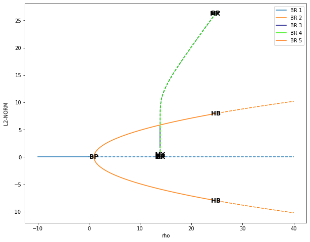

```python
ax = b.plot_fixed_points_diagram(variables=('rho','x'))
b.plot_periodic_orbits_diagram(ax=ax, cmap='gist_ncar');
```

We can also plot both the bifurcation diagram and the solutions for a given value of $\rho$:

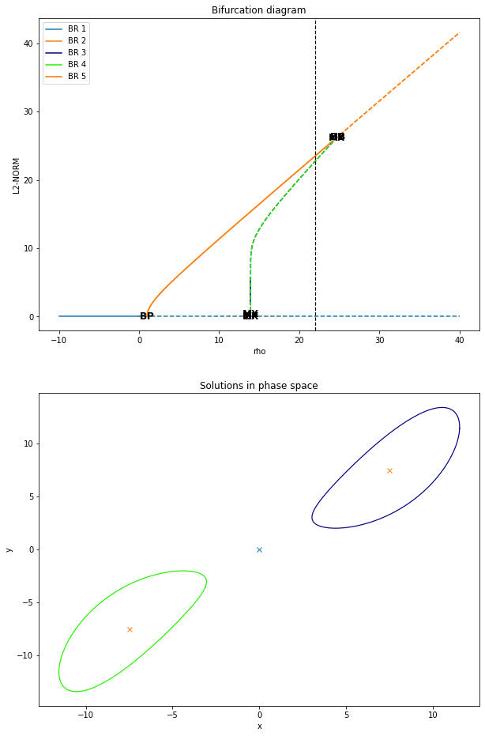

```python
b.plot_diagram_and_solutions(22., diagram_variables=(('NORM')), solutions_variables=(0, 1), fixed_points_diagram_kwargs={'legend': True},
                             periodic_orbits_diagram_kwargs={'cmap': 'gist_ncar'});
```

or plot a single branch and its solutions:

```
array([<Axes: title={'center': 'Bifurcation diagram - Branch 4'}, xlabel='rho', ylabel='L2-NORM'>,
       <Axes: title={'center': 'Solutions in phase space'}, xlabel='x', ylabel='y'>],
      dtype=object)
```

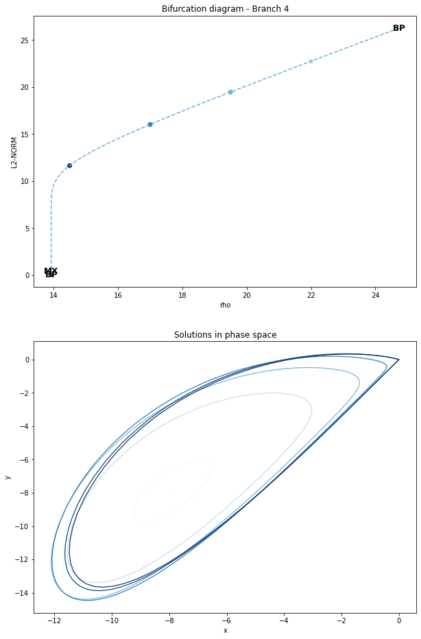

```python
# plotting branch 4
b.plot_single_po_branch_and_solutions(4, cmap='Blues_r')
```

You can compare these results with the animated figure at the top of the notebook. We can also plot the result in 3 dimensions to get a better view:

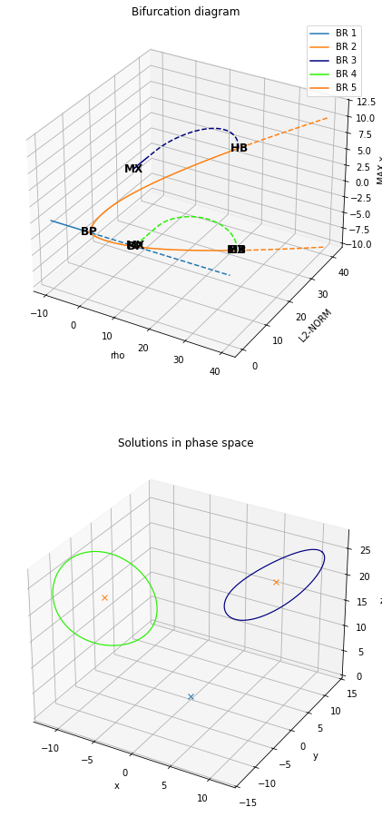

```python
b.plot_diagram_in_3D_and_solutions_in_3D(22., solutions_variables=(0, 1, 2), fixed_points_diagram_kwargs={},
                                         periodic_orbits_diagram_kwargs={'cmap': 'gist_ncar'});
```

Finally, it is not hard to also plot the dynamics on the attractor (represented by the long trajectory computed beforehand) on top of the solutions to see their relevance:

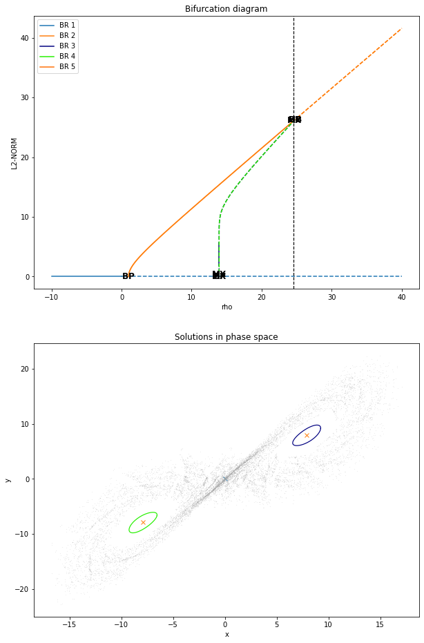

```python
axs = b.plot_diagram_and_solutions(24.5, solutions_variables=(0, 1), fixed_points_diagram_kwargs={'legend': True},
                             periodic_orbits_diagram_kwargs={'cmap': 'gist_ncar'})
axs[1].plot(trajectory['y'][0], trajectory['y'][1], marker='o', ms=0.07, ls='', color='darkgray')
```

One can see that the chaotic dynamics is constrained by the two found periodic orbits. In fact, for $\rho=24.5$ (and values around), the basin of the Lorenz attractor is shielded away from the two stable symmetric equilibrium states by the 2D cylinder-shaped stable manifolds of the two “threshold” saddle orbits seen here.

The two found periodic orbits also connect to the unstable fixed point if we vary $\sigma$. Indeed, one can restart the continuations along $\sigma$ in AUTO² using the `restart_and_change_continuation_parameters` method which yield a new bifurcation diagram object:

```python
continuation_kwargs = {'ICP':['sigma'], 'NMX': 300, 'UZSTOP': {'sigma':[0.5,50.]}, 'UZR': {'sigma': [3.67, 3.7]+list(np.arange(2.5, 45., 2.5))}}

new_b = b.restart_and_change_continuation_parameters(24.5, end_level=2, extra_comparison_parameters=['x', 'y'], comparison_tol=[1.e-1] * 3,
                                             fixed_points_continuation_kwargs=continuation_kwargs,
                                             periodic_orbits_continuation_kwargs=continuation_kwargs)
```

```
2025-11-03 17:13:46,195 INFO: Model lrz -- Cont. Param. sigma -- Module bifurcations.py -- Starting a new bifurcation diagram along parameter sigma.
2025-11-03 17:13:46,195 INFO: Model lrz -- Cont. Param. sigma -- Module bifurcations.py -- Starting a new bifurcation diagram along parameter sigma.
2025-11-03 17:13:46,198 INFO: Model lrz -- Cont. Param. sigma -- Module bifurcations.py -- Files will be loaded from and saved in the folder ./from_rho_24.500_continuation_along_sigma.
2025-11-03 17:13:46,198 INFO: Model lrz -- Cont. Param. sigma -- Module bifurcations.py -- Files will be loaded from and saved in the folder ./from_rho_24.500_continuation_along_sigma.
2025-11-03 17:13:46,201 INFO: Model lrz -- Cont. Param. sigma -- Module bifurcations.py -- Logs related to this diagram can be found in the ./from_rho_24.500_continuation_along_sigma/auto2_lrz_sigma.log file.
2025-11-03 17:13:46,201 INFO: Model lrz -- Cont. Param. sigma -- Module bifurcations.py -- Logs related to this diagram can be found in the ./from_rho_24.500_continuation_along_sigma/auto2_lrz_sigma.log file.
2025-11-03 17:13:46,205 INFO: Model lrz -- Cont. Param. sigma -- Module bifurcations.py -- Starting the computation of the fixed points bifurcation diagram with model lrz.
2025-11-03 17:13:46,205 INFO: Model lrz -- Cont. Param. sigma -- Module bifurcations.py -- Starting the computation of the fixed points bifurcation diagram with model lrz.
2025-11-03 17:13:46,207 INFO: Model lrz -- Cont. Param. sigma -- Module bifurcations.py -- Continuing provided fixed points.
2025-11-03 17:13:46,207 INFO: Model lrz -- Cont. Param. sigma -- Module bifurcations.py -- Continuing provided fixed points.
```

```
Runner configured
Starting lrz ...

  BR    PT  TY  LAB     sigma        L2-NORM          x             y             z
   1     4  UZ   16   2.50000E+01   0.00000E+00   0.00000E+00   0.00000E+00   0.00000E+00
   1    10  UZ   17   2.75000E+01   0.00000E+00   0.00000E+00   0.00000E+00   0.00000E+00
   1    15  UZ   18   3.00000E+01   0.00000E+00   0.00000E+00   0.00000E+00   0.00000E+00
   1    20  UZ   19   3.25000E+01   0.00000E+00   0.00000E+00   0.00000E+00   0.00000E+00
   1    25  UZ   20   3.50000E+01   0.00000E+00   0.00000E+00   0.00000E+00   0.00000E+00
   1    30  UZ   21   3.75000E+01   0.00000E+00   0.00000E+00   0.00000E+00   0.00000E+00
   1    35  UZ   22   4.00000E+01   0.00000E+00   0.00000E+00   0.00000E+00   0.00000E+00
   1    40  UZ   23   4.25000E+01   0.00000E+00   0.00000E+00   0.00000E+00   0.00000E+00
   1    55  UZ   24   5.00000E+01   0.00000E+00   0.00000E+00   0.00000E+00   0.00000E+00

 Total Time    0.309E-02
lrz ... done
Runner configured
Starting lrz ...

  BR    PT  TY  LAB     sigma        L2-NORM          x             y             z
   1     7  UZ   16   2.25000E+01   0.00000E+00   0.00000E+00   0.00000E+00   0.00000E+00
   1    12  UZ   17   2.00000E+01   0.00000E+00   0.00000E+00   0.00000E+00   0.00000E+00
   1    17  UZ   18   1.75000E+01   0.00000E+00   0.00000E+00   0.00000E+00   0.00000E+00
   1    22  UZ   19   1.50000E+01   0.00000E+00   0.00000E+00   0.00000E+00   0.00000E+00
   1    27  UZ   20   1.25000E+01   0.00000E+00   0.00000E+00   0.00000E+00   0.00000E+00
   1    32  UZ   21   1.00000E+01   0.00000E+00   0.00000E+00   0.00000E+00   0.00000E+00
   1    37  UZ   22   7.50000E+00   0.00000E+00   0.00000E+00   0.00000E+00   0.00000E+00
   1    42  UZ   23   5.00000E+00   0.00000E+00   0.00000E+00   0.00000E+00   0.00000E+00
   1    45  UZ   24   3.70000E+00   0.00000E+00   0.00000E+00   0.00000E+00   0.00000E+00
   1    46  UZ   25   3.67000E+00   0.00000E+00   0.00000E+00   0.00000E+00   0.00000E+00
   1    49  UZ   26   2.50000E+00   0.00000E+00   0.00000E+00   0.00000E+00   0.00000E+00
   1    53  UZ   27   5.00000E-01   0.00000E+00   0.00000E+00   0.00000E+00   0.00000E+00

 Total Time    0.316E-02
lrz ... done
```

```
2025-11-03 17:13:46,420 INFO: Model lrz -- Cont. Param. sigma -- Module bifurcations.py -- Saving valid branch 1 emanating from detected fixed point 1.
2025-11-03 17:13:46,420 INFO: Model lrz -- Cont. Param. sigma -- Module bifurcations.py -- Saving valid branch 1 emanating from detected fixed point 1.
```

```
Runner configured
Starting lrz ...

  BR    PT  TY  LAB     sigma        L2-NORM          x             y             z
   2     8  UZ   30   2.25000E+01   2.60304E+01  -7.91623E+00  -7.91623E+00   2.35000E+01
   2    13  UZ   31   2.00000E+01   2.60304E+01  -7.91623E+00  -7.91623E+00   2.35000E+01
   2    18  UZ   32   1.75000E+01   2.60304E+01  -7.91623E+00  -7.91623E+00   2.35000E+01
   2    23  UZ   33   1.50000E+01   2.60304E+01  -7.91623E+00  -7.91623E+00   2.35000E+01
   2    28  UZ   34   1.25000E+01   2.60304E+01  -7.91623E+00  -7.91623E+00   2.35000E+01
   2    33  UZ   35   1.00000E+01   2.60304E+01  -7.91623E+00  -7.91623E+00   2.35000E+01
   2    38  UZ   36   7.50000E+00   2.60304E+01  -7.91623E+00  -7.91623E+00   2.35000E+01
   2    43  UZ   37   5.00000E+00   2.60304E+01  -7.91623E+00  -7.91623E+00   2.35000E+01
   2    46  UZ   38   3.70000E+00   2.60304E+01  -7.91623E+00  -7.91623E+00   2.35000E+01
   2    47  UZ   39   3.67000E+00   2.60304E+01  -7.91623E+00  -7.91623E+00   2.35000E+01
   2    50  UZ   40   2.50000E+00   2.60304E+01  -7.91623E+00  -7.91623E+00   2.35000E+01
   2    54  UZ   41   5.00000E-01   2.60304E+01  -7.91623E+00  -7.91623E+00   2.35000E+01

 Total Time    0.392E-02
lrz ... done
Runner configured
Starting lrz ...

  BR    PT  TY  LAB     sigma        L2-NORM          x             y             z
   2     5  UZ   30   2.50000E+01   2.60304E+01  -7.91623E+00  -7.91623E+00   2.35000E+01
   2    11  UZ   31   2.75000E+01   2.60304E+01  -7.91623E+00  -7.91623E+00   2.35000E+01
   2    16  UZ   32   3.00000E+01   2.60304E+01  -7.91623E+00  -7.91623E+00   2.35000E+01
   2    21  UZ   33   3.25000E+01   2.60304E+01  -7.91623E+00  -7.91623E+00   2.35000E+01
   2    26  UZ   34   3.50000E+01   2.60304E+01  -7.91623E+00  -7.91623E+00   2.35000E+01
   2    31  UZ   35   3.75000E+01   2.60304E+01  -7.91623E+00  -7.91623E+00   2.35000E+01
   2    36  UZ   36   4.00000E+01   2.60304E+01  -7.91623E+00  -7.91623E+00   2.35000E+01
   2    41  UZ   37   4.25000E+01   2.60304E+01  -7.91623E+00  -7.91623E+00   2.35000E+01
   2    56  UZ   38   5.00000E+01   2.60304E+01  -7.91623E+00  -7.91623E+00   2.35000E+01

 Total Time    0.378E-02
lrz ... done
```

```
2025-11-03 17:13:46,661 INFO: Model lrz -- Cont. Param. sigma -- Module bifurcations.py -- Saving valid branch 2 emanating from detected fixed point 2.
2025-11-03 17:13:46,661 INFO: Model lrz -- Cont. Param. sigma -- Module bifurcations.py -- Saving valid branch 2 emanating from detected fixed point 2.
```

```
Runner configured
Starting lrz ...

  BR    PT  TY  LAB     sigma        L2-NORM          x             y             z
   3     5  UZ   30   2.50000E+01   2.60304E+01   7.91623E+00   7.91623E+00   2.35000E+01
   3    11  UZ   31   2.75000E+01   2.60304E+01   7.91623E+00   7.91623E+00   2.35000E+01
   3    16  UZ   32   3.00000E+01   2.60304E+01   7.91623E+00   7.91623E+00   2.35000E+01
   3    21  UZ   33   3.25000E+01   2.60304E+01   7.91623E+00   7.91623E+00   2.35000E+01
   3    26  UZ   34   3.50000E+01   2.60304E+01   7.91623E+00   7.91623E+00   2.35000E+01
   3    31  UZ   35   3.75000E+01   2.60304E+01   7.91623E+00   7.91623E+00   2.35000E+01
   3    36  UZ   36   4.00000E+01   2.60304E+01   7.91623E+00   7.91623E+00   2.35000E+01
   3    41  UZ   37   4.25000E+01   2.60304E+01   7.91623E+00   7.91623E+00   2.35000E+01
   3    56  UZ   38   5.00000E+01   2.60304E+01   7.91623E+00   7.91623E+00   2.35000E+01

 Total Time    0.366E-02
lrz ... done
Runner configured
Starting lrz ...

  BR    PT  TY  LAB     sigma        L2-NORM          x             y             z
   3     8  UZ   30   2.25000E+01   2.60304E+01   7.91623E+00   7.91623E+00   2.35000E+01
   3    13  UZ   31   2.00000E+01   2.60304E+01   7.91623E+00   7.91623E+00   2.35000E+01
   3    18  UZ   32   1.75000E+01   2.60304E+01   7.91623E+00   7.91623E+00   2.35000E+01
   3    23  UZ   33   1.50000E+01   2.60304E+01   7.91623E+00   7.91623E+00   2.35000E+01
   3    28  UZ   34   1.25000E+01   2.60304E+01   7.91623E+00   7.91623E+00   2.35000E+01
   3    33  UZ   35   1.00000E+01   2.60304E+01   7.91623E+00   7.91623E+00   2.35000E+01
   3    38  UZ   36   7.50000E+00   2.60304E+01   7.91623E+00   7.91623E+00   2.35000E+01
   3    43  UZ   37   5.00000E+00   2.60304E+01   7.91623E+00   7.91623E+00   2.35000E+01
   3    46  UZ   38   3.70000E+00   2.60304E+01   7.91623E+00   7.91623E+00   2.35000E+01
   3    47  UZ   39   3.67000E+00   2.60304E+01   7.91623E+00   7.91623E+00   2.35000E+01
   3    50  UZ   40   2.50000E+00   2.60304E+01   7.91623E+00   7.91623E+00   2.35000E+01
   3    54  UZ   41   5.00000E-01   2.60304E+01   7.91623E+00   7.91623E+00   2.35000E+01

 Total Time    0.369E-02
lrz ... done
```

[output not shown]

[output cut: 20 more lines]

```
Runner configured
Starting lrz ...

  BR    PT  TY  LAB     sigma        L2-NORM        MAX x         MAX y         MAX z           T
   4    18  UZ   36   1.25000E+01   2.57046E+01   1.09937E+01   1.20320E+01   2.85684E+01   6.64626E-01
   4    26  UZ   37   1.50000E+01   2.52977E+01   1.26134E+01   1.39616E+01   3.08741E+01   6.89175E-01
   4    33  UZ   38   1.75000E+01   2.48641E+01   1.39314E+01   1.54364E+01   3.26025E+01   7.24133E-01
   4    40  UZ   39   2.00000E+01   2.44369E+01   1.50386E+01   1.66155E+01   3.39591E+01   7.64999E-01
   4    46  UZ   40   2.25000E+01   2.40202E+01   1.59988E+01   1.76015E+01   3.50813E+01   8.09681E-01
   4    52  UZ   41   2.50000E+01   2.36089E+01   1.68495E+01   1.84549E+01   3.60354E+01   8.57376E-01
   4    58  UZ   42   2.74999E+01   2.31943E+01   1.76264E+01   1.92147E+01   3.68779E+01   9.08200E-01
   4    64  UZ   43   3.00000E+01   2.27658E+01   1.83407E+01   1.99080E+01   3.76377E+01   9.63056E-01
   4    70  UZ   44   3.25000E+01   2.23106E+01   1.90165E+01   2.05576E+01   3.83412E+01   1.02365E+00
   4    76  UZ   45   3.50000E+01   2.18111E+01   1.96615E+01   2.11807E+01   3.90033E+01   1.09279E+00
   4    82  UZ   46   3.75000E+01   2.12419E+01   2.02835E+01   2.17830E+01   3.96459E+01   1.17513E+00
   4    88  UZ   47   4.00000E+01   2.05618E+01   2.09050E+01   2.23822E+01   4.02822E+01   1.27904E+00
   4    94  UZ   48   4.25000E+01   1.96920E+01   2.15136E+01   2.29783E+01   4.09084E+01   1.42226E+00
   4   169  BP   49   4.78928E+01   1.44209E+00   2.28440E+01   2.42509E+01   4.22427E+01   7.86027E+03
   4   172  MX   50   4.78928E+01   1.44552E+00   2.28452E+01   2.42727E+01   4.22659E+01   7.61833E+03

 Total Time    0.200E+00
lrz ... done
Runner configured
Starting lrz ...

  BR    PT  TY  LAB     sigma        L2-NORM        MAX x         MAX y         MAX z           T
   4    19  UZ   36   7.50000E+00   2.57140E+01   1.05101E+01   1.22351E+01   2.85341E+01   7.08999E-01
   4    38  UZ   37   5.00000E+00   2.35688E+01   1.30071E+01   1.91989E+01   3.54645E+01   9.47933E-01
   4    66  UZ   38   3.70000E+00   1.63525E+01   1.36923E+01   2.39152E+01   3.96068E+01   2.17281E+00
   4    72  UZ   39   3.67000E+00   1.45203E+01   1.37033E+01   2.40374E+01   3.97119E+01   2.76318E+00
   4   129  MX   40   3.66219E+00   3.95511E-02   1.36025E+01   2.40597E+01   3.95310E+01   3.72692E+05

 Total Time    0.830E-01
lrz ... done
```

```
2025-11-03 17:13:47,475 INFO: Model lrz -- Cont. Param. sigma -- Module bifurcations.py -- Saving valid branch 4 emanating from provided initial data.
2025-11-03 17:13:47,475 INFO: Model lrz -- Cont. Param. sigma -- Module bifurcations.py -- Saving valid branch 4 emanating from provided initial data.
2025-11-03 17:13:47,477 INFO: Model lrz -- Cont. Param. sigma -- Module bifurcations.py -- There might be new periodic orbit branches to compute. You might want to restart the automatic computation of the bifurcation diagram.
2025-11-03 17:13:47,477 INFO: Model lrz -- Cont. Param. sigma -- Module bifurcations.py -- There might be new periodic orbit branches to compute. You might want to restart the automatic computation of the bifurcation diagram.
2025-11-03 17:13:47,478 INFO: Model lrz -- Cont. Param. sigma -- Module bifurcations.py -- Continuing extra PO with provided initial data
2025-11-03 17:13:47,478 INFO: Model lrz -- Cont. Param. sigma -- Module bifurcations.py -- Continuing extra PO with provided initial data
```

```
Runner configured
Starting lrz ...

  BR    PT  TY  LAB     sigma        L2-NORM        MAX x         MAX y         MAX z           T
   5    19  UZ   38   7.50000E+00   2.57140E+01  -5.10689E+00  -3.74191E+00   2.85337E+01   7.08999E-01
   5    38  UZ   39   5.00000E+00   2.35688E+01  -1.51722E+00   2.56825E+00   3.54618E+01   9.47933E-01
   5    66  UZ   40   3.70000E+00   1.63525E+01  -6.82257E-03   6.39509E+00   3.96025E+01   2.17281E+00
   5    72  UZ   41   3.67000E+00   1.45203E+01  -4.77525E-04   6.48825E+00   3.97065E+01   2.76320E+00
   5   127  MX   42   3.66231E+00   4.34632E-01   1.87507E-05   6.49005E+00   3.97377E+01   2.38776E+04

 Total Time    0.990E-01
lrz ... done
Runner configured
Starting lrz ...

  BR    PT  TY  LAB     sigma        L2-NORM        MAX x         MAX y         MAX z           T
   5    18  UZ   38   1.25000E+01   2.57046E+01  -4.68999E+00  -4.02848E+00   2.85694E+01   6.64626E-01
   5    26  UZ   39   1.50000E+01   2.52977E+01  -3.04104E+00  -2.47170E+00   3.08738E+01   6.89175E-01
   5    33  UZ   40   1.75000E+01   2.48641E+01  -1.88225E+00  -1.48700E+00   3.26028E+01   7.24133E-01
   5    40  UZ   41   2.00000E+01   2.44369E+01  -1.11761E+00  -8.71073E-01   3.39620E+01   7.64999E-01
   5    46  UZ   42   2.25000E+01   2.40202E+01  -6.34211E-01  -4.91697E-01   3.50794E+01   8.09681E-01
   5    52  UZ   43   2.50000E+01   2.36089E+01  -3.42441E-01  -2.64190E-01   3.60357E+01   8.57376E-01
   5    58  UZ   44   2.74999E+01   2.31943E+01  -1.74063E-01  -1.32875E-01   3.68757E+01   9.08201E-01
   5    64  UZ   45   3.00000E+01   2.27658E+01  -8.19189E-02  -6.11214E-02   3.76377E+01   9.63057E-01
   5    70  UZ   46   3.25000E+01   2.23106E+01  -3.47328E-02  -2.46533E-02   3.83412E+01   1.02365E+00
   5    76  UZ   47   3.50000E+01   2.18110E+01  -1.27251E-02  -8.08034E-03   3.90070E+01   1.09279E+00
   5    82  UZ   48   3.75000E+01   2.12419E+01  -3.77313E-03  -1.73512E-03   3.96483E+01   1.17513E+00
   5    88  UZ   49   4.00000E+01   2.05618E+01  -7.86450E-04   5.15373E-05   4.02842E+01   1.27904E+00
   5    94  UZ   50   4.25000E+01   1.96920E+01  -9.24324E-05   2.42397E-04   4.09135E+01   1.42226E+00
   5   167  BP   51   4.78920E+01   3.19797E-01   3.11142E-06   6.28511E-05   4.22608E+01   6.62029E+03
   5   169  MX   52   4.78916E+01   4.72895E-01   1.62458E-06   2.10169E-05   4.22696E+01   6.20406E+03

 Total Time    0.157E+00
```

```
2025-11-03 17:13:47,893 INFO: Model lrz -- Cont. Param. sigma -- Module bifurcations.py -- Not storing full results of PO point at ['sigma', 'T'] = [np.float64(10.0), np.float64(0.66110933719)] (branch 4) because it repeats itself (forward).
Saving only the relevant part. NMX set to 73
2025-11-03 17:13:47,893 INFO: Model lrz -- Cont. Param. sigma -- Module bifurcations.py -- Not storing full results of PO point at ['sigma', 'T'] = [np.float64(10.0), np.float64(0.66110933719)] (branch 4) because it repeats itself (forward).
Saving only the relevant part. NMX set to 73
```

```
lrz ... done
Runner configured
Starting lrz ...

  BR    PT  TY  LAB     sigma        L2-NORM        MAX x         MAX y         MAX z           T
   5    19  UZ   38   7.50000E+00   2.57140E+01  -5.10689E+00  -3.74191E+00   2.85337E+01   7.08999E-01
   5    38  UZ   39   5.00000E+00   2.35688E+01  -1.51722E+00   2.56825E+00   3.54618E+01   9.47933E-01
   5    66  UZ   40   3.70000E+00   1.63525E+01  -6.82257E-03   6.39509E+00   3.96025E+01   2.17281E+00
   5    72  UZ   41   3.67000E+00   1.45203E+01  -4.77525E-04   6.48825E+00   3.97065E+01   2.76320E+00
   5    73  EP   42   3.66781E+00   1.42034E+01  -2.71546E-04   6.49739E+00   3.97164E+01   2.88844E+00

 Total Time    0.574E-01
lrz ... done
```

```
2025-11-03 17:13:48,129 INFO: Model lrz -- Cont. Param. sigma -- Module bifurcations.py -- Saving valid branch 5 emanating from provided initial data.
2025-11-03 17:13:48,129 INFO: Model lrz -- Cont. Param. sigma -- Module bifurcations.py -- Saving valid branch 5 emanating from provided initial data.
2025-11-03 17:13:48,130 INFO: Model lrz -- Cont. Param. sigma -- Module bifurcations.py -- There might be new periodic orbit branches to compute. You might want to restart the automatic computation of the bifurcation diagram.
2025-11-03 17:13:48,130 INFO: Model lrz -- Cont. Param. sigma -- Module bifurcations.py -- There might be new periodic orbit branches to compute. You might want to restart the automatic computation of the bifurcation diagram.
2025-11-03 17:13:48,132 INFO: Model lrz -- Cont. Param. rho -- Module bifurcations.py -- Beginning computation of the periodic orbits from detected branching and period doubling points.
2025-11-03 17:13:48,133 INFO: Model lrz -- Cont. Param. rho -- Module bifurcations.py -- Computation up to level 2 was asked but bifurcation diagram is complete.
2025-11-03 17:13:48,133 INFO: Model lrz -- Cont. Param. rho -- Module bifurcations.py -- Nothing more to compute.
```

and plot the diagram and solutions for $\sigma = 20$ :

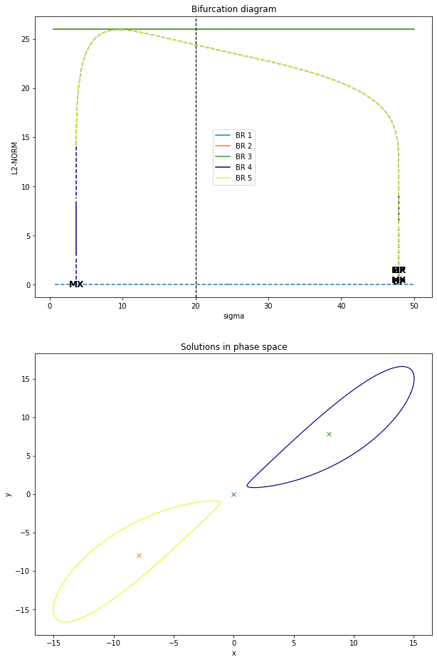

```python
new_b.plot_diagram_and_solutions(20., solutions_variables=(0, 1), fixed_points_diagram_kwargs={'legend': True},
                             periodic_orbits_diagram_kwargs={'cmap': 'gist_ncar'});
```

In particular, plotting the two branches shows double homoclinic connections:

```
array([<Axes: title={'center': 'Bifurcation diagram - Branch 5'}, xlabel='sigma', ylabel='L2-NORM'>,
       <Axes: title={'center': 'Solutions in phase space'}, xlabel='x', ylabel='y'>],
      dtype=object)
```

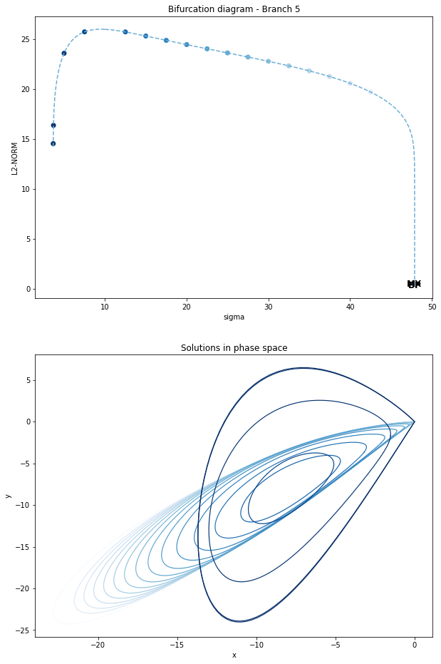

```python
new_b.plot_single_po_branch_and_solutions(5, cmap='Blues_r')
```

This is particularly evident in 3D :

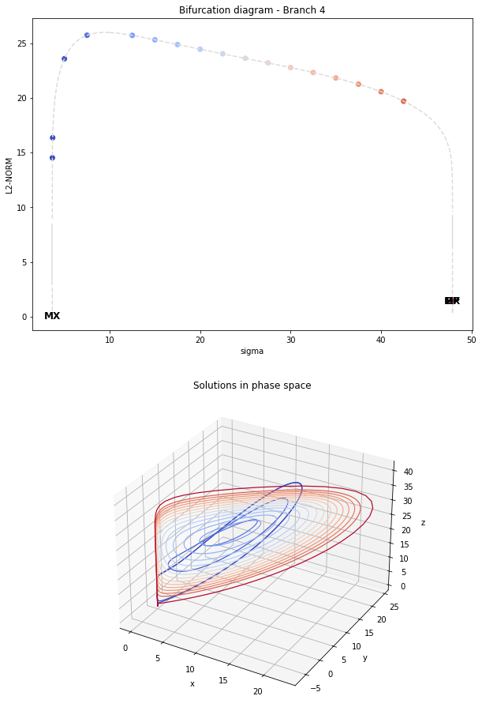

```python
new_b.plot_single_po_branch_and_solutions_3D(4, cmap='coolwarm');
```

For more information about the Lorenz bifurcation diagram, see Section 2.2 of Barrio et al. (2012) (see reference at the top of the notebook).